# Intro

Streamlit app can be found here: https://andreas-fluckiger-mandatory-ind320.streamlit.app

The Github repository can be found here: https://github.com/Fluckigerandreas/Mandatory_assignment_IND320.git

# Some libraries and requirements for my notebook

```python
import os
import pandas as pd
from pyspark.sql import SparkSession
from pyspark.sql.types import StructType, StructField, StringType, TimestampType, DoubleType
import seaborn as sns
from datetime import datetime, timedelta
from dateutil.relativedelta import relativedelta

import os

# ✅ Java 11 path
os.environ["JAVA_HOME"] = "/Library/Java/JavaVirtualMachines/jdk-11.jdk/Contents/Home"

# ✅ Use your current Python environment for PySpark
os.environ["PYSPARK_PYTHON"] = "python"
os.environ["PYSPARK_DRIVER_PYTHON"] = "python"
```

# Requirements for creating my spark session

```python
from pyspark.sql import SparkSession

spark = SparkSession.builder \
    .appName("Elhub Production to Cassandra") \
    .config("spark.jars.packages", "com.datastax.spark:spark-cassandra-connector_2.12:3.5.0") \
    .config("spark.cassandra.connection.host", "127.0.0.1") \
    .config("spark.cassandra.connection.port", "9042") \
    .config("spark.cassandra.auth.username", "cassandra") \
    .config("spark.cassandra.auth.password", "cassandra") \
    .config("spark.cassandra.output.consistency.level", "LOCAL_QUORUM") \
    .config("spark.sql.extensions", "com.datastax.spark.connector.CassandraSparkExtensions") \
    .getOrCreate()

print("✅ SparkSession successfully connected to Cassandra on localhost:9042")
```

```
:: loading settings :: url = jar:file:/Users/andreasfluckiger/Desktop/IND320/.venv/lib/python3.11/site-packages/pyspark/jars/ivy-2.5.1.jar!/org/apache/ivy/core/settings/ivysettings.xml
```

[output not shown]

```
✅ SparkSession successfully connected to Cassandra on localhost:9042
```

# Extracting data from API and adding to Cassandra

```python
# %% [code]
import requests
import pandas as pd
from datetime import datetime
from dateutil.relativedelta import relativedelta

# --- API Settings ---
BASE_URL = "https://api.elhub.no/energy-data/v0/price-areas"
DATASET = "PRODUCTION_PER_GROUP_MBA_HOUR"
START_DATE = "2021-01-01"
END_DATE = "2021-12-31"

# --- Step 1: Get all available price areas dynamically ---
areas_response = requests.get(BASE_URL)
if areas_response.status_code == 200:
    areas = areas_response.json().get("priceAreas", ["NO1", "NO2", "NO3", "NO4", "NO5"])
else:
    print("⚠️ Could not fetch price areas from API. Using defaults (NO1-NO5).")
    areas = ["NO1", "NO2", "NO3", "NO4", "NO5"]

print(f"📍 Price areas to fetch: {areas}")


# --- Step 2: Function to fetch data for one area and time window ---
def fetch_data(area, start_date, end_date):
    api_url = f"{BASE_URL}/{area}"
    params = {
        "dataset": DATASET,
        "startDate": start_date,
        "endDate": end_date
    }
    response = requests.get(api_url, params=params)

    if response.status_code == 200:
        try:
            data = response.json()
            records = data["data"][0]["attributes"]["productionPerGroupMbaHour"]
            if records:
                df = pd.DataFrame(records)
                df["priceArea"] = area
                return df
            else:
                print(f"⚠️ No data returned for {area}: {start_date} → {end_date}")
                return pd.DataFrame()
        except (KeyError, IndexError):
            print(f"⚠️ Unexpected JSON structure for {area}: {start_date} → {end_date}")
            return pd.DataFrame()
    else:
        print(f"⚠️ Failed for {area}: {start_date} → {end_date} ({response.status_code})")
        return pd.DataFrame()


# --- Step 3: Loop over all months and all areas ---
all_data = []
start_dt = datetime.fromisoformat(START_DATE + "T00:00:00+02:00")
end_dt = datetime.fromisoformat(END_DATE + "T23:59:59+02:00")

for area in areas:
    current_start = start_dt
    while current_start < end_dt:
        current_end = current_start + relativedelta(months=1)
        if current_end > end_dt:
            current_end = end_dt

        start_str = current_start.isoformat()
        end_str = current_end.isoformat()

        print(f"Fetching {area}: {start_str} → {end_str}")
        df = fetch_data(area, start_str, end_str)
        if not df.empty:
            all_data.append(df)

        current_start = current_end


# --- Step 4: Combine and save all data ---
if all_data:
    final_df = pd.concat(all_data, ignore_index=True)
    final_df.to_csv("elhub_production_2021_all_areas.csv", index=False)
    print(f"✅ Data for all price areas saved to elhub_production_2021_all_areas.csv")
else:
    print("⚠️ No data collected.")

# %% [markdown]
# ## 2️⃣ Insert into Cassandra using Spark
from pyspark.sql.types import StructType, StructField, StringType, FloatType, DoubleType

schema = StructType([
    StructField("endTime", StringType(), True),
    StructField("lastUpdatedTime", StringType(), True),
    StructField("priceArea", StringType(), True),
    StructField("productionGroup", StringType(), True),
    StructField("quantityKwh", DoubleType(), True),
    StructField("startTime", StringType(), True),
])

# --- Convert Pandas DF to Spark DF ---
spark_df = spark.createDataFrame(final_df, schema=schema)

# --- Rename columns to match Cassandra primary key casing ---
spark_df = spark_df \
    .withColumnRenamed("endTime", "endtime") \
    .withColumnRenamed("lastUpdatedTime", "lastupdatedtime") \
    .withColumnRenamed("priceArea", "pricearea") \
    .withColumnRenamed("productionGroup", "productiongroup") \
    .withColumnRenamed("quantityKwh", "quantitykwh") \
    .withColumnRenamed("startTime", "starttime") \

# I ran this the first time, to make sure my code sent the data to cassandra. I also store a csv file locally on my computer
"""
# --- Write to Cassandra ---
spark_df.write \
    .format("org.apache.spark.sql.cassandra") \
    .mode("append") \
    .options(keyspace="elhub", table="production_2021") \
    .save()

"""
```

```
📍 Price areas to fetch: ['NO1', 'NO2', 'NO3', 'NO4', 'NO5']
Fetching NO1: 2021-01-01T00:00:00+02:00 → 2021-02-01T00:00:00+02:00
Fetching NO1: 2021-02-01T00:00:00+02:00 → 2021-03-01T00:00:00+02:00
Fetching NO1: 2021-03-01T00:00:00+02:00 → 2021-04-01T00:00:00+02:00
Fetching NO1: 2021-04-01T00:00:00+02:00 → 2021-05-01T00:00:00+02:00
Fetching NO1: 2021-05-01T00:00:00+02:00 → 2021-06-01T00:00:00+02:00
Fetching NO1: 2021-06-01T00:00:00+02:00 → 2021-07-01T00:00:00+02:00
Fetching NO1: 2021-07-01T00:00:00+02:00 → 2021-08-01T00:00:00+02:00
Fetching NO1: 2021-08-01T00:00:00+02:00 → 2021-09-01T00:00:00+02:00
Fetching NO1: 2021-09-01T00:00:00+02:00 → 2021-10-01T00:00:00+02:00
Fetching NO1: 2021-10-01T00:00:00+02:00 → 2021-11-01T00:00:00+02:00
Fetching NO1: 2021-11-01T00:00:00+02:00 → 2021-12-01T00:00:00+02:00
Fetching NO1: 2021-12-01T00:00:00+02:00 → 2021-12-31T23:59:59+02:00
Fetching NO2: 2021-01-01T00:00:00+02:00 → 2021-02-01T00:00:00+02:00
Fetching NO2: 2021-02-01T00:00:00+02:00 → 2021-03-01T00:00:00+02:00
Fetching NO2: 2021-03-01T00:00:00+02:00 → 2021-04-01T00:00:00+02:00
Fetching NO2: 2021-04-01T00:00:00+02:00 → 2021-05-01T00:00:00+02:00
Fetching NO2: 2021-05-01T00:00:00+02:00 → 2021-06-01T00:00:00+02:00
Fetching NO2: 2021-06-01T00:00:00+02:00 → 2021-07-01T00:00:00+02:00
Fetching NO2: 2021-07-01T00:00:00+02:00 → 2021-08-01T00:00:00+02:00
Fetching NO2: 2021-08-01T00:00:00+02:00 → 2021-09-01T00:00:00+02:00
Fetching NO2: 2021-09-01T00:00:00+02:00 → 2021-10-01T00:00:00+02:00
Fetching NO2: 2021-10-01T00:00:00+02:00 → 2021-11-01T00:00:00+02:00
Fetching NO2: 2021-11-01T00:00:00+02:00 → 2021-12-01T00:00:00+02:00
Fetching NO2: 2021-12-01T00:00:00+02:00 → 2021-12-31T23:59:59+02:00
Fetching NO3: 2021-01-01T00:00:00+02:00 → 2021-02-01T00:00:00+02:00
Fetching NO3: 2021-02-01T00:00:00+02:00 → 2021-03-01T00:00:00+02:00
Fetching NO3: 2021-03-01T00:00:00+02:00 → 2021-04-01T00:00:00+02:00
Fetching NO3: 2021-04-01T00:00:00+02:00 → 2021-05-01T00:00:00+02:00
Fetching NO3: 2021-05-01T00:00:00+02:00 → 2021-06-01T00:00:00+02:00
Fetching NO3: 2021-06-01T00:00:00+02:00 → 2021-07-01T00:00:00+02:00
Fetching NO3: 2021-07-01T00:00:00+02:00 → 2021-08-01T00:00:00+02:00
Fetching NO3: 2021-08-01T00:00:00+02:00 → 2021-09-01T00:00:00+02:00
Fetching NO3: 2021-09-01T00:00:00+02:00 → 2021-10-01T00:00:00+02:00
Fetching NO3: 2021-10-01T00:00:00+02:00 → 2021-11-01T00:00:00+02:00
Fetching NO3: 2021-11-01T00:00:00+02:00 → 2021-12-01T00:00:00+02:00
Fetching NO3: 2021-12-01T00:00:00+02:00 → 2021-12-31T23:59:59+02:00
Fetching NO4: 2021-01-01T00:00:00+02:00 → 2021-02-01T00:00:00+02:00
Fetching NO4: 2021-02-01T00:00:00+02:00 → 2021-03-01T00:00:00+02:00
Fetching NO4: 2021-03-01T00:00:00+02:00 → 2021-04-01T00:00:00+02:00
Fetching NO4: 2021-04-01T00:00:00+02:00 → 2021-05-01T00:00:00+02:00
Fetching NO4: 2021-05-01T00:00:00+02:00 → 2021-06-01T00:00:00+02:00
Fetching NO4: 2021-06-01T00:00:00+02:00 → 2021-07-01T00:00:00+02:00
Fetching NO4: 2021-07-01T00:00:00+02:00 → 2021-08-01T00:00:00+02:00
Fetching NO4: 2021-08-01T00:00:00+02:00 → 2021-09-01T00:00:00+02:00
Fetching NO4: 2021-09-01T00:00:00+02:00 → 2021-10-01T00:00:00+02:00
Fetching NO4: 2021-10-01T00:00:00+02:00 → 2021-11-01T00:00:00+02:00
Fetching NO4: 2021-11-01T00:00:00+02:00 → 2021-12-01T00:00:00+02:00
Fetching NO4: 2021-12-01T00:00:00+02:00 → 2021-12-31T23:59:59+02:00
Fetching NO5: 2021-01-01T00:00:00+02:00 → 2021-02-01T00:00:00+02:00
Fetching NO5: 2021-02-01T00:00:00+02:00 → 2021-03-01T00:00:00+02:00
Fetching NO5: 2021-03-01T00:00:00+02:00 → 2021-04-01T00:00:00+02:00
Fetching NO5: 2021-04-01T00:00:00+02:00 → 2021-05-01T00:00:00+02:00
Fetching NO5: 2021-05-01T00:00:00+02:00 → 2021-06-01T00:00:00+02:00
Fetching NO5: 2021-06-01T00:00:00+02:00 → 2021-07-01T00:00:00+02:00
Fetching NO5: 2021-07-01T00:00:00+02:00 → 2021-08-01T00:00:00+02:00
Fetching NO5: 2021-08-01T00:00:00+02:00 → 2021-09-01T00:00:00+02:00
Fetching NO5: 2021-09-01T00:00:00+02:00 → 2021-10-01T00:00:00+02:00
Fetching NO5: 2021-10-01T00:00:00+02:00 → 2021-11-01T00:00:00+02:00
Fetching NO5: 2021-11-01T00:00:00+02:00 → 2021-12-01T00:00:00+02:00
Fetching NO5: 2021-12-01T00:00:00+02:00 → 2021-12-31T23:59:59+02:00
✅ Data for all price areas saved to elhub_production_2021_all_areas.csv
```

```
'\n# --- Write to Cassandra ---\nspark_df.write     .format("org.apache.spark.sql.cassandra")     .mode("append")     .options(keyspace="elhub", table="production_2021")     .save()\n\n'
```

# Extracting filtered data from Cassandra

```python
from pyspark.sql import SparkSession
from pyspark.sql.functions import col

# Assuming SparkSession 'spark' is already created with Cassandra connector
keyspace = "elhub"
table = "production_2021"

# Load only the needed columns
df = spark.read \
    .format("org.apache.spark.sql.cassandra") \
    .options(keyspace=keyspace, table=table) \
    .load() \
    .select("pricearea", "productiongroup", "starttime", "quantitykwh")

# Convert to Pandas for plotting
pdf = df.toPandas()
```

[output not shown]

# Plotting of data extracted from cassandra

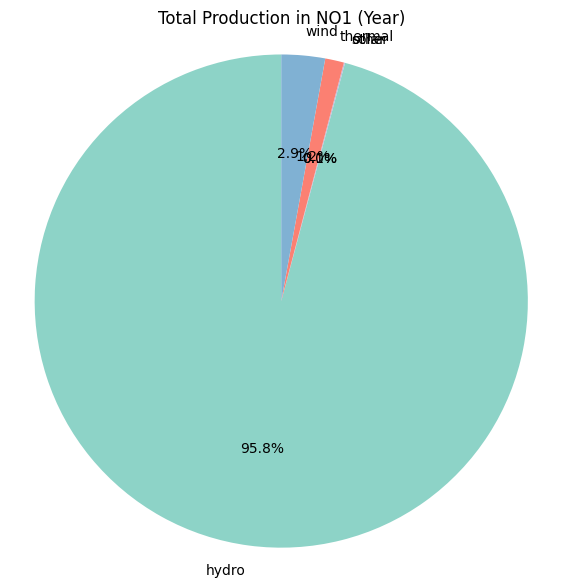

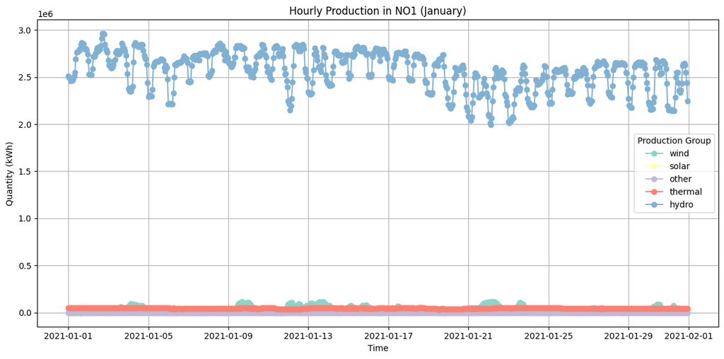

```python
import pandas as pd
import matplotlib.pyplot as plt

# --- Choose your price area ---
chosen_area = "NO1"

# --- Filter for the chosen price area ---
df_area = pdf[pdf["pricearea"] == chosen_area].copy()

# Convert time columns to datetime
df_area["starttime"] = pd.to_datetime(df_area["starttime"])

# -----------------------------
# 1️⃣ Pie chart: total production by production group for the year
# -----------------------------
total_by_group = df_area.groupby("productiongroup")["quantitykwh"].sum()

# Define colors (similar to Plotly qualitative Set3)
colors = plt.get_cmap('Set3').colors  # Matplotlib has Set3 colormap

plt.figure(figsize=(7,7))
plt.pie(
    total_by_group,
    labels=total_by_group.index,
    autopct='%1.1f%%',
    colors=colors[:len(total_by_group)],
    startangle=90
)
plt.title(f"Total Production in {chosen_area} (Year)")
plt.axis('equal')  # Equal aspect ratio ensures pie is circular
plt.show()

# -----------------------------
# 2️⃣ Line plot: first month of the year
# -----------------------------
df_january = df_area[df_area["starttime"].dt.month == 1]

plt.figure(figsize=(12,6))
for i, group in enumerate(df_january["productiongroup"].unique()):
    group_data = df_january[df_january["productiongroup"] == group]
    plt.plot(
        group_data["starttime"],
        group_data["quantitykwh"],
        label=group,
        marker='o',
        color=colors[i % len(colors)]
    )

plt.title(f"Hourly Production in {chosen_area} (January)")
plt.xlabel("Time")
plt.ylabel("Quantity (kWh)")
plt.grid(True)
plt.legend(title="Production Group")
plt.tight_layout()
plt.show()
```

# Adding dataframe from cassandra to MongoDB

```python
import os, sys
sys.path.append(os.getcwd())

from mysecrets import USERNAME, PASSWORD
from pymongo.mongo_client import MongoClient
from pymongo.server_api import ServerApi
import certifi

# Use certifi for trusted CA certificate bundle
ca = certifi.where()

# Construct the URI using the imported credentials
uri = f"mongodb+srv://{USERNAME}:{PASSWORD}@cluster0.chffuae.mongodb.net/?retryWrites=true&w=majority&appName=Cluster0"

# Create client with TLS certificate
client = MongoClient(uri, server_api=ServerApi('1'), tls=True, tlsCAFile=ca)

# Ping the deployment
try:
    client.admin.command('ping')
    print("✅ Pinged your MongoDB deployment — connection successful!")
except Exception as e:
    print("❌ Connection failed:")
    print(e)
```

```
✅ Pinged your MongoDB deployment — connection successful!
```

```python
# Selecting a database and a collection
database = client['example']
collection = database['data']

try:
    # Convert DataFrame rows to a list of dictionaries
    data = pdf.to_dict("records")

    if data:
        collection.insert_many(data)
except:
    # Completely ignore any errors
    pass
```

# Work description and log

For the second compulsory assignment, a significant portion of time was dedicated to resolving dependency issues. After extensive trial and error, we successfully configured the environment using Spark 3.5.0, NumPy 2.3.4, and Python 3.11.9. This setup has proven stable and reliable for the tasks at hand, allowing us to focus more on the actual data processing rather than environment issues. It was a valuable learning experience in handling version conflicts and understanding the subtle compatibility requirements of modern data science libraries.

For data visualization, I opted to use Plotly. The interactive nature of Plotly plots provided a more dynamic exploration of the data, making it easier to gain insights and compare different subsets of the dataset. Hover information, zooming capabilities, and the ability to filter data interactively greatly enhanced the efficiency of the analysis. This approach contrasts with static plots, which can be less flexible when analyzing large and complex datasets. For the notebook, I had to use matplotlib because of the conversion to pdf-file for the hand-in.

Regarding data storage and management, the following code was used to write data to Cassandra:

--- Write to Cassandra --- spark_df.write  
.format("org.apache.spark.sql.cassandra")  
.mode("append")  
.options(keyspace="elhub", table="production_2021")  
.save()

In addition, I encountered some issues related to GitHub password security. Since the GitHub account was used to store scripts and datasets, ensuring strong passwords and enabling two-factor authentication was critical. There were concerns about potential exposure of sensitive credentials in public repositories, highlighting the importance of using environment variables or .gitignore files to prevent accidental commits of passwords and API keys. This experience reinforced best practices for secure coding and version control in collaborative projects.

For the next assignment, I would like to have more time to format tables and plots properly, as some dimensions still look slightly off compared to the Jupyter Notebook. Improving this will make the visualizations more readable and professional.

# AI

Throughout this project, I leveraged ChatGPT to assist with code development and syntax guidance. While my older hardware occasionally led to repetitive loops during AI-assisted code generation, the tool was particularly valuable for analyzing and troubleshooting error messages. Using AI in this manner significantly accelerated debugging and improved overall workflow efficiency.